# Least Squares Linear Model Theory

Suppose that our data generating process is:

$$\begin{array}{lcl} \mathbf{y} &=&
\mathbf{X}\beta + \epsilon \\
\epsilon &{\sim}& \text{N}\Big(0 \space, \hspace{3mm} \sigma^2\mathbf{I}\Big)
\end{array}$$

$\mathbf{y}$ is an $n\times 1$ vector.

$\mathbf{X}$ is an $n\times p$ matrix.

$\epsilon$ is an $n\times 1$ vector.

$\epsilon$ is a random vector, and thus $\mathbf{y}$ is a random vector too (since its value is dependent on $\epsilon$). $\mathbf{X}$ and $\beta$ are fixed ($\mathbf{X}$ and $\beta$ are the same in all datasets generated by this process).

This implies that random vector $\mathbf{y}$ has a multivariate normal distribution $\mathbf{y}\sim\text{N}\Big(\mathbf{X}\beta \space, \hspace{3mm} \sigma^2\mathbf{I}\Big)$

For a single given dataset $\{\mathbf{y},\mathbf{X}\}$, where outcome vector $\mathbf{y}$ and features/predictors $\mathbf{X}$ are known, we would want to estimate parameter/coefficient vector $\beta$.

The estimator $\hat \beta$ minimising the *sum of squared errors* $\epsilon'\epsilon=\sum_{i=1}^n\Big(\mathbf{y}-\underset{\hat{ \mathbf{y}}}{\underbrace{X \hat\beta}}\Big)^2$ for a given sample is $\hat \beta = (X'X)^{-1}X'\mathbf{y}$. This is called the *Ordinary Least Squares* (OLS) estimator.

The distribution of this estimator $\hat\beta$ across samples, under this data-generating process, is multivariate normal:

$$\hat\beta \quad\sim\quad \text{N}_p\Big(\beta \space, \hspace{3mm} \sigma^2 (X'X)^{-1}\Big)$$

```r
beta
```

```
[1]  0 -1  0  2
```

If $\sigma^2$ were known, then this information could be used to generate confidence intervals for $\hat\beta$.

In practice, confidence intervals are generated using the distribution of $\hat\beta$ and an estimate $s=\hat{\sigma^2}$ of $\sigma^2$.

The estimated errors for a particular dataset are $\hat \epsilon = \underset{\hat{\mathbf{y}}}{\underbrace{X\hat\beta}} - \mathbf{y}$.

The expected value of $\hat\epsilon'\hat\epsilon$ across datasets is $E\Big[\hat\epsilon'\hat\epsilon\Big]=\sigma^2\Big(n-p\Big)$, which gives us an estimator

$$\hat{\sigma^2}=\displaystyle\frac{\hat\epsilon'\hat\epsilon}{n-p}$$

of $\sigma^2$, since

$$E\Big[\displaystyle\frac{\hat\epsilon'\hat\epsilon}{n-p}\Big]=\displaystyle\frac{1}{n-p}E\Big[\hat\epsilon'\hat\epsilon\Big]=\sigma^2$$

Here is an example of the distribution of $\hat{\sigma^2}$ across multiple datasets by simulation:

```r
# use the same values of [X] and [sigma] as the simulation above

store_sigma_estimators <- rep(NA,10000)       # create a vector to store sigma estimate from each sample

for( i in 1:10000 ){      # run 10,000 simulations

  e <- rnorm(n, mean=0, sd=sigma)                   # generate the errors
  y <- X %*% beta + e                               # generate y
  ols_beta_hat <- solve( t(X)%*%X ) %*% t(X) %*% y    # calculate the OLS estimator of beta
  y_hat <- X %*% ols_beta_hat                       # calculate the predicted values of y
  sample_errors <- y_hat - y                        # calculate the predicted errors for this dataset
  store_sigma_estimators[i] <- ( t(sample_errors)%*%sample_errors ) / (n-p)
}

hist(      x = store_sigma_estimators,
      breaks = 50,
        main = bquote("Distribution of"~hat(sigma^2) )
    )

# draw in true sigma^2 value:
abline( v = sigma^2, lwd=3 )
```

[output not shown]

[output not shown]

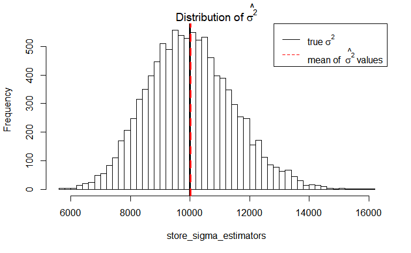

```r
abline( v = mean(store_sigma_estimators), lwd=3, col=2, lty=2 )

# draw a legend on the plot:
legend( "topright",
        lty = c(1,2),
        col = c(1,2),
        legend = c( as.expression( bquote("true"~sigma^2) ) ,
                    as.expression( bquote("mean of "~hat(sigma^2)~"values") )
                  )
      )
```

In order to test the hypothesis $\beta_j=0$ (i.e. whether a particular coefficient $\beta_j$ is 0), we can use the result

$$\begin{array}{lcl}
t_j &=& \displaystyle\frac{\hat\beta_j}{\text{SE}\Big[\hat\beta_j\Big]} \quad=\quad \displaystyle\frac{\hat\beta_j}{\sqrt{\Big[\sigma^2(X^TX)^{-1}\Big]_{jj}}} \\
t_j &\sim& \text{t}_{n-p} \quad \text{ if the null hypothesis } (H_0:\beta_j=0) \text{ is true} \end{array}$$

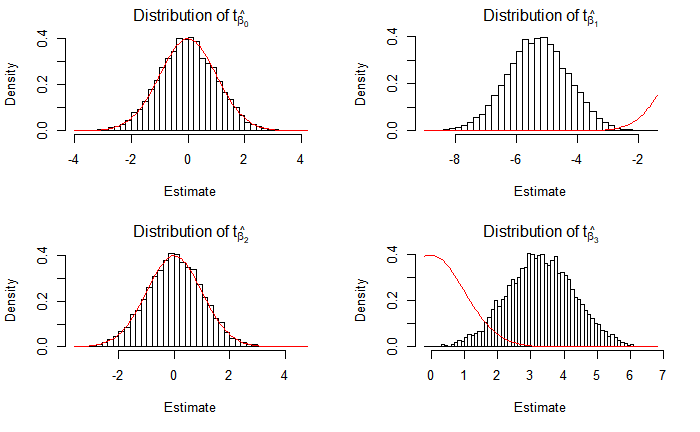

```r
store_estimates <- matrix( rep(NA,4*10000), ncol=4 )       # create a matrix to store the ols_beta_hat estimates
colnames(store_estimates) <- c("t_b0", "t_b1", "t_b2", "t_b3")   # name columns of the matrix created above

for( i in 1:10000 ){      # run 10,000 simulations

  e <- rnorm(n, mean=0, sd=sigma)           # generate the errors
  y <- X %*% beta + e                        # generate y
  cov_beta_hat <- sigma^2 * solve( t(X)%*%X )   # calculate the variance/covariance matrix of beta_hat estimators
  ols_beta_hat <- solve( t(X)%*%X ) %*% t(X) %*% y    # calculate the OLS estimator of beta
  store_estimates[i,] <- c(ols_beta_hat) / sqrt( diag(cov_beta_hat) )    # store the t-statistics
}

# plot the distributions of the t statistics generated in the simulation above:
par( mfrow=c(2,2) )
for( i in 1:4 ){
  hist(      x = store_estimates[,i],
        breaks = 50,
          main = bquote("Distribution of"~t[hat(beta[.(i-1)])] ),
          xlab = "Estimate",
          freq = FALSE
      )
  curve( dt( x,
             df = n-p
            ),
         add = TRUE,
         col = 2
       )
}
```

# When to consider estimators of $\beta$ other than OLS

From reference [1]:

1. If errors are correlated or have unequal variance ($\sigma^2$ is not constant across samples 1,..,n), then *Generalized Least Squares* should be used to estimate $\hat \beta$.
2. If the error distribution is long-tailed, then *robust estimators* of $\hat \beta$ should be considered.
3. When the features/predictors are highly correlated (collinear), then penalised (biased) estimators should be considered (e.g. Ridge regression, Lasso).

# References

1. https://cran.r-project.org/doc/contrib/Faraway-PRA.pdf